# Project 2 Preliminary Report

## Group Members

Specify the names and EIDs of all group members (if not working in a group just put your own name and EID): Andy Park, AP59864

## Dataset

Identify the dataset you plan to work with (provide a link to it if possible if it is not one of the suggested datasets): ’Austin_Crash_Report_Data_-_Crash_Level_Records_20250407.csv.gz`

## Question

Specify the question you plan to ask/answer with this dataset: Knowing which factors (lighting, road surface, time of day, etc.) drive injury crashes can help Austin PD and city planners target safety interventions.

*Can we predict whether a crash will be fatal?*

By pinpointing conditions, such aslighting, road surface quality, and time of day that most often lead to fatal crashes, I can give Austin PD and city planners the insights they need to target their safety interventions more effectively.

## Outcome Variable

What is the outcome variable in your dataset that you will be predicting? **For the purposes of this project, the outcome should either be continuous or binary**.

The outcome variable is crash_fatal_fl, which indicates whether the crash was fatal as True or non‑fatal as a False. It is a binary, which is categorical variable, so I plan to use logistic regression to compare it later to tree based method.

## Outcome Summary

Provide a summary plot of the outcome variable. For example, if it is a continuous variable, show a histogram or a boxplot. If it is a binary variable, show a barplot.

```r
library(tidyverse)
crash <- read_csv("Austin_Crash_Report_Data_-_Crash_Level_Records_20250407.csv.gz")
crash <- crash %>%
  mutate(fatal = fct_recode(
    as_factor(crash_fatal_fl),
    "NonFatal" = "FALSE", "Fatal" = "TRUE"))
crash %>%
  count(fatal)
```

```
## # A tibble: 2 × 2
##   fatal         n
##   <fct>     <int>
## 1 NonFatal 215378
## 2 Fatal      1224
```

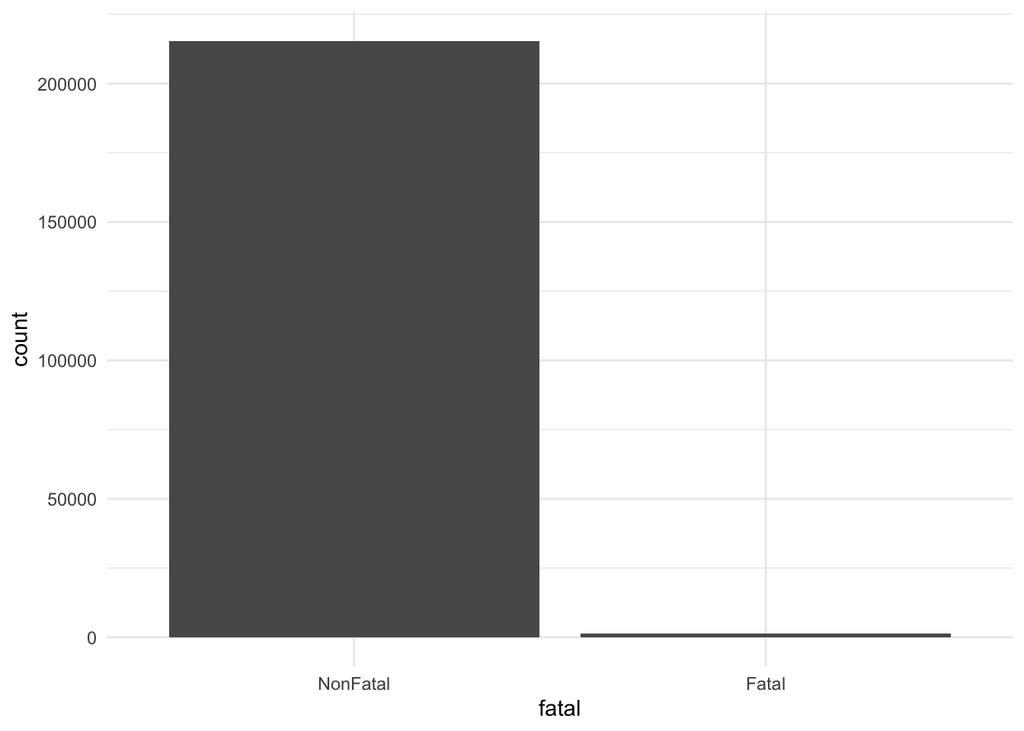

```r
ggplot(crash, aes(x = fatal)) +
  geom_bar() +
  labs() +
  theme_minimal()
```

## Submission to Gradescope

**Make sure to add your group members to the Gradescope submission!**